# Risk Factor Analysis

## Outcome Variable

**Outcome Variable:** ever_swasted

## Predictor Variables

**Intervention Variable:** enstunt

**Adjustment Set:**

- arm
- sex
- W_mage
- meducyrs
- feducyrs
- vagbrth
- single
- brthmon
- W_parity
- delta_W_mage
- delta_meducyrs
- delta_feducyrs
- delta_vagbrth
- delta_single
- delta_brthmon
- delta_W_parity

## Stratifying Variables

The analysis was stratified on these variable(s):

- agecat
- studyid
- country

## Data Summary

| agecat | studyid | country | enstunt | ever_swasted | n_cell | n |
| --- | --- | --- | --- | --- | --- | --- |
| 0-24 months (no birth wast) | CMC-V-BCS-2002 | INDIA | 0 | 0 | 249 | 368 |
| 0-24 months (no birth wast) | CMC-V-BCS-2002 | INDIA | 0 | 1 | 44 | 368 |
| 0-24 months (no birth wast) | CMC-V-BCS-2002 | INDIA | 1 | 0 | 64 | 368 |
| 0-24 months (no birth wast) | CMC-V-BCS-2002 | INDIA | 1 | 1 | 11 | 368 |
| 0-24 months (no birth wast) | CMIN | BANGLADESH | 0 | 0 | 149 | 268 |
| 0-24 months (no birth wast) | CMIN | BANGLADESH | 0 | 1 | 17 | 268 |
| 0-24 months (no birth wast) | CMIN | BANGLADESH | 1 | 0 | 82 | 268 |
| 0-24 months (no birth wast) | CMIN | BANGLADESH | 1 | 1 | 20 | 268 |
| 0-24 months (no birth wast) | COHORTS | GUATEMALA | 0 | 0 | 1003 | 1332 |
| 0-24 months (no birth wast) | COHORTS | GUATEMALA | 0 | 1 | 10 | 1332 |
| 0-24 months (no birth wast) | COHORTS | GUATEMALA | 1 | 0 | 302 | 1332 |
| 0-24 months (no birth wast) | COHORTS | GUATEMALA | 1 | 1 | 17 | 1332 |
| 0-24 months (no birth wast) | COHORTS | INDIA | 0 | 0 | 6014 | 7135 |
| 0-24 months (no birth wast) | COHORTS | INDIA | 0 | 1 | 274 | 7135 |
| 0-24 months (no birth wast) | COHORTS | INDIA | 1 | 0 | 784 | 7135 |
| 0-24 months (no birth wast) | COHORTS | INDIA | 1 | 1 | 63 | 7135 |
| 0-24 months (no birth wast) | COHORTS | PHILIPPINES | 0 | 0 | 2617 | 3019 |
| 0-24 months (no birth wast) | COHORTS | PHILIPPINES | 0 | 1 | 228 | 3019 |
| 0-24 months (no birth wast) | COHORTS | PHILIPPINES | 1 | 0 | 153 | 3019 |
| 0-24 months (no birth wast) | COHORTS | PHILIPPINES | 1 | 1 | 21 | 3019 |
| 0-24 months (no birth wast) | CONTENT | PERU | 0 | 0 | 194 | 215 |
| 0-24 months (no birth wast) | CONTENT | PERU | 0 | 1 | 1 | 215 |
| 0-24 months (no birth wast) | CONTENT | PERU | 1 | 0 | 20 | 215 |
| 0-24 months (no birth wast) | CONTENT | PERU | 1 | 1 | 0 | 215 |
| 0-24 months (no birth wast) | EE | PAKISTAN | 0 | 0 | 183 | 377 |
| 0-24 months (no birth wast) | EE | PAKISTAN | 0 | 1 | 28 | 377 |
| 0-24 months (no birth wast) | EE | PAKISTAN | 1 | 0 | 128 | 377 |
| 0-24 months (no birth wast) | EE | PAKISTAN | 1 | 1 | 38 | 377 |
| 0-24 months (no birth wast) | GMS-Nepal | NEPAL | 0 | 0 | 441 | 660 |
| 0-24 months (no birth wast) | GMS-Nepal | NEPAL | 0 | 1 | 112 | 660 |

[output cut: 338 more lines]

The following strata were considered:

- agecat: 0-24 months (no birth wast), studyid: CMC-V-BCS-2002, country: INDIA
- agecat: 0-24 months (no birth wast), studyid: CMIN, country: BANGLADESH
- agecat: 0-24 months (no birth wast), studyid: COHORTS, country: GUATEMALA
- agecat: 0-24 months (no birth wast), studyid: COHORTS, country: INDIA
- agecat: 0-24 months (no birth wast), studyid: COHORTS, country: PHILIPPINES
- agecat: 0-24 months (no birth wast), studyid: CONTENT, country: PERU
- agecat: 0-24 months (no birth wast), studyid: EE, country: PAKISTAN
- agecat: 0-24 months (no birth wast), studyid: GMS-Nepal, country: NEPAL
- agecat: 0-24 months (no birth wast), studyid: Guatemala BSC, country: GUATEMALA
- agecat: 0-24 months (no birth wast), studyid: iLiNS-Zinc, country: BURKINA FASO
- agecat: 0-24 months (no birth wast), studyid: IRC, country: INDIA
- agecat: 0-24 months (no birth wast), studyid: JiVitA-3, country: BANGLADESH
- agecat: 0-24 months (no birth wast), studyid: JiVitA-4, country: BANGLADESH
- agecat: 0-24 months (no birth wast), studyid: Keneba, country: GAMBIA
- agecat: 0-24 months (no birth wast), studyid: LCNI-5, country: MALAWI
- agecat: 0-24 months (no birth wast), studyid: MAL-ED, country: BANGLADESH
- agecat: 0-24 months (no birth wast), studyid: MAL-ED, country: BRAZIL
- agecat: 0-24 months (no birth wast), studyid: MAL-ED, country: INDIA
- agecat: 0-24 months (no birth wast), studyid: MAL-ED, country: NEPAL
- agecat: 0-24 months (no birth wast), studyid: MAL-ED, country: PERU
- agecat: 0-24 months (no birth wast), studyid: MAL-ED, country: SOUTH AFRICA
- agecat: 0-24 months (no birth wast), studyid: MAL-ED, country: TANZANIA, UNITED REPUBLIC OF
- agecat: 0-24 months (no birth wast), studyid: NIH-Birth, country: BANGLADESH
- agecat: 0-24 months (no birth wast), studyid: NIH-Crypto, country: BANGLADESH
- agecat: 0-24 months (no birth wast), studyid: PROBIT, country: BELARUS
- agecat: 0-24 months (no birth wast), studyid: PROVIDE, country: BANGLADESH
- agecat: 0-24 months (no birth wast), studyid: ResPak, country: PAKISTAN
- agecat: 0-24 months (no birth wast), studyid: SAS-CompFeed, country: INDIA
- agecat: 0-24 months (no birth wast), studyid: SAS-FoodSuppl, country: INDIA
- agecat: 0-24 months (no birth wast), studyid: TanzaniaChild2, country: TANZANIA, UNITED REPUBLIC OF
- agecat: 0-24 months (no birth wast), studyid: ZVITAMBO, country: ZIMBABWE
- agecat: 0-6 months (no birth wast), studyid: CMC-V-BCS-2002, country: INDIA
- agecat: 0-6 months (no birth wast), studyid: CMIN, country: BANGLADESH
- agecat: 0-6 months (no birth wast), studyid: COHORTS, country: GUATEMALA
- agecat: 0-6 months (no birth wast), studyid: COHORTS, country: INDIA
- agecat: 0-6 months (no birth wast), studyid: COHORTS, country: PHILIPPINES
- agecat: 0-6 months (no birth wast), studyid: CONTENT, country: PERU
- agecat: 0-6 months (no birth wast), studyid: EE, country: PAKISTAN
- agecat: 0-6 months (no birth wast), studyid: GMS-Nepal, country: NEPAL
- agecat: 0-6 months (no birth wast), studyid: Guatemala BSC, country: GUATEMALA
- agecat: 0-6 months (no birth wast), studyid: IRC, country: INDIA
- agecat: 0-6 months (no birth wast), studyid: JiVitA-3, country: BANGLADESH
- agecat: 0-6 months (no birth wast), studyid: JiVitA-4, country: BANGLADESH
- agecat: 0-6 months (no birth wast), studyid: Keneba, country: GAMBIA
- agecat: 0-6 months (no birth wast), studyid: LCNI-5, country: MALAWI
- agecat: 0-6 months (no birth wast), studyid: MAL-ED, country: BANGLADESH
- agecat: 0-6 months (no birth wast), studyid: MAL-ED, country: BRAZIL
- agecat: 0-6 months (no birth wast), studyid: MAL-ED, country: INDIA
- agecat: 0-6 months (no birth wast), studyid: MAL-ED, country: NEPAL
- agecat: 0-6 months (no birth wast), studyid: MAL-ED, country: PERU
- agecat: 0-6 months (no birth wast), studyid: MAL-ED, country: SOUTH AFRICA
- agecat: 0-6 months (no birth wast), studyid: MAL-ED, country: TANZANIA, UNITED REPUBLIC OF
- agecat: 0-6 months (no birth wast), studyid: NIH-Birth, country: BANGLADESH
- agecat: 0-6 months (no birth wast), studyid: NIH-Crypto, country: BANGLADESH
- agecat: 0-6 months (no birth wast), studyid: PROBIT, country: BELARUS
- agecat: 0-6 months (no birth wast), studyid: PROVIDE, country: BANGLADESH
- agecat: 0-6 months (no birth wast), studyid: ResPak, country: PAKISTAN
- agecat: 0-6 months (no birth wast), studyid: SAS-CompFeed, country: INDIA
- agecat: 0-6 months (no birth wast), studyid: SAS-FoodSuppl, country: INDIA
- agecat: 0-6 months (no birth wast), studyid: TanzaniaChild2, country: TANZANIA, UNITED REPUBLIC OF
- agecat: 0-6 months (no birth wast), studyid: ZVITAMBO, country: ZIMBABWE
- agecat: 6-24 months, studyid: CMC-V-BCS-2002, country: INDIA
- agecat: 6-24 months, studyid: CMIN, country: BANGLADESH
- agecat: 6-24 months, studyid: COHORTS, country: GUATEMALA
- agecat: 6-24 months, studyid: COHORTS, country: INDIA
- agecat: 6-24 months, studyid: COHORTS, country: PHILIPPINES
- agecat: 6-24 months, studyid: CONTENT, country: PERU
- agecat: 6-24 months, studyid: EE, country: PAKISTAN
- agecat: 6-24 months, studyid: GMS-Nepal, country: NEPAL
- agecat: 6-24 months, studyid: Guatemala BSC, country: GUATEMALA
- agecat: 6-24 months, studyid: iLiNS-Zinc, country: BURKINA FASO
- agecat: 6-24 months, studyid: IRC, country: INDIA
- agecat: 6-24 months, studyid: JiVitA-3, country: BANGLADESH
- agecat: 6-24 months, studyid: JiVitA-4, country: BANGLADESH
- agecat: 6-24 months, studyid: Keneba, country: GAMBIA
- agecat: 6-24 months, studyid: LCNI-5, country: MALAWI
- agecat: 6-24 months, studyid: MAL-ED, country: BANGLADESH
- agecat: 6-24 months, studyid: MAL-ED, country: BRAZIL
- agecat: 6-24 months, studyid: MAL-ED, country: INDIA
- agecat: 6-24 months, studyid: MAL-ED, country: NEPAL
- agecat: 6-24 months, studyid: MAL-ED, country: PERU
- agecat: 6-24 months, studyid: MAL-ED, country: SOUTH AFRICA
- agecat: 6-24 months, studyid: MAL-ED, country: TANZANIA, UNITED REPUBLIC OF
- agecat: 6-24 months, studyid: NIH-Birth, country: BANGLADESH
- agecat: 6-24 months, studyid: NIH-Crypto, country: BANGLADESH
- agecat: 6-24 months, studyid: PROBIT, country: BELARUS
- agecat: 6-24 months, studyid: PROVIDE, country: BANGLADESH
- agecat: 6-24 months, studyid: ResPak, country: PAKISTAN
- agecat: 6-24 months, studyid: SAS-CompFeed, country: INDIA
- agecat: 6-24 months, studyid: SAS-FoodSuppl, country: INDIA
- agecat: 6-24 months, studyid: TanzaniaChild2, country: TANZANIA, UNITED REPUBLIC OF
- agecat: 6-24 months, studyid: ZVITAMBO, country: ZIMBABWE

### Dropped Strata

Some strata were dropped due to rare outcomes:

- agecat: 0-24 months (no birth wast), studyid: CONTENT, country: PERU
- agecat: 0-24 months (no birth wast), studyid: Guatemala BSC, country: GUATEMALA
- agecat: 0-24 months (no birth wast), studyid: LCNI-5, country: MALAWI
- agecat: 0-24 months (no birth wast), studyid: MAL-ED, country: BANGLADESH
- agecat: 0-24 months (no birth wast), studyid: MAL-ED, country: BRAZIL
- agecat: 0-24 months (no birth wast), studyid: MAL-ED, country: INDIA
- agecat: 0-24 months (no birth wast), studyid: MAL-ED, country: NEPAL
- agecat: 0-24 months (no birth wast), studyid: MAL-ED, country: PERU
- agecat: 0-24 months (no birth wast), studyid: MAL-ED, country: SOUTH AFRICA
- agecat: 0-24 months (no birth wast), studyid: MAL-ED, country: TANZANIA, UNITED REPUBLIC OF
- agecat: 0-24 months (no birth wast), studyid: PROBIT, country: BELARUS
- agecat: 0-24 months (no birth wast), studyid: PROVIDE, country: BANGLADESH
- agecat: 0-6 months (no birth wast), studyid: CMC-V-BCS-2002, country: INDIA
- agecat: 0-6 months (no birth wast), studyid: CMIN, country: BANGLADESH
- agecat: 0-6 months (no birth wast), studyid: COHORTS, country: GUATEMALA
- agecat: 0-6 months (no birth wast), studyid: COHORTS, country: PHILIPPINES
- agecat: 0-6 months (no birth wast), studyid: CONTENT, country: PERU
- agecat: 0-6 months (no birth wast), studyid: GMS-Nepal, country: NEPAL
- agecat: 0-6 months (no birth wast), studyid: Guatemala BSC, country: GUATEMALA
- agecat: 0-6 months (no birth wast), studyid: IRC, country: INDIA
- agecat: 0-6 months (no birth wast), studyid: LCNI-5, country: MALAWI
- agecat: 0-6 months (no birth wast), studyid: MAL-ED, country: BANGLADESH
- agecat: 0-6 months (no birth wast), studyid: MAL-ED, country: BRAZIL
- agecat: 0-6 months (no birth wast), studyid: MAL-ED, country: INDIA
- agecat: 0-6 months (no birth wast), studyid: MAL-ED, country: NEPAL
- agecat: 0-6 months (no birth wast), studyid: MAL-ED, country: PERU
- agecat: 0-6 months (no birth wast), studyid: MAL-ED, country: SOUTH AFRICA
- agecat: 0-6 months (no birth wast), studyid: MAL-ED, country: TANZANIA, UNITED REPUBLIC OF
- agecat: 0-6 months (no birth wast), studyid: NIH-Birth, country: BANGLADESH
- agecat: 0-6 months (no birth wast), studyid: NIH-Crypto, country: BANGLADESH
- agecat: 0-6 months (no birth wast), studyid: PROBIT, country: BELARUS
- agecat: 0-6 months (no birth wast), studyid: PROVIDE, country: BANGLADESH
- agecat: 0-6 months (no birth wast), studyid: SAS-FoodSuppl, country: INDIA
- agecat: 0-6 months (no birth wast), studyid: TanzaniaChild2, country: TANZANIA, UNITED REPUBLIC OF
- agecat: 6-24 months, studyid: CONTENT, country: PERU
- agecat: 6-24 months, studyid: Guatemala BSC, country: GUATEMALA
- agecat: 6-24 months, studyid: LCNI-5, country: MALAWI
- agecat: 6-24 months, studyid: MAL-ED, country: BANGLADESH
- agecat: 6-24 months, studyid: MAL-ED, country: BRAZIL
- agecat: 6-24 months, studyid: MAL-ED, country: INDIA
- agecat: 6-24 months, studyid: MAL-ED, country: NEPAL
- agecat: 6-24 months, studyid: MAL-ED, country: PERU
- agecat: 6-24 months, studyid: MAL-ED, country: SOUTH AFRICA
- agecat: 6-24 months, studyid: MAL-ED, country: TANZANIA, UNITED REPUBLIC OF
- agecat: 6-24 months, studyid: PROBIT, country: BELARUS
- agecat: 6-24 months, studyid: PROVIDE, country: BANGLADESH

## Methods Detail

We’re interested in the causal parameters $E[Y_a]$ for all values of $a \in \mathcal{A}$. These parameters represent the mean outcome if, possibly contrary to fact, we intervened to set all units to have $A=a$. Under the randomization and positivity assumptions, these are identified by the statistical parameters $\psi_a=E_W[E_{Y|A,W}(Y|A=a,W)]$. In addition, we’re interested in the mean of $Y$, $E[Y]$ under no intervention (the observed mean). We will estimate these parameters by using SuperLearner to fit the relevant likelihood factors – $E_{Y|A,W}(Y|A=a,W)$ and $p(A=a|W)$, and then updating our likelihood fit using a joint TMLE.

For unadjusted analyses ($W=\{\}$), initial likelihoods were estimated using Lrnr_glm to estimate the simple $E(Y|A)$ and Lrnr_mean to estimate $p(A)$. For adjusted analyses, a small library containing Lrnr_glmnet, Lrnr_xgboost, and Lrnr_mean was used.

Having estimated these parameters, we will then use the delta method to estimate relative risks and attributable risks relative to a prespecified baseline level of $A$.

# Results Detail

## Results Plots

[figure not shown]

[figure not shown]

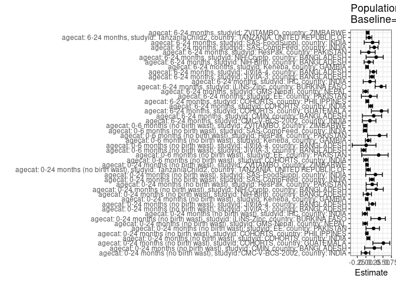

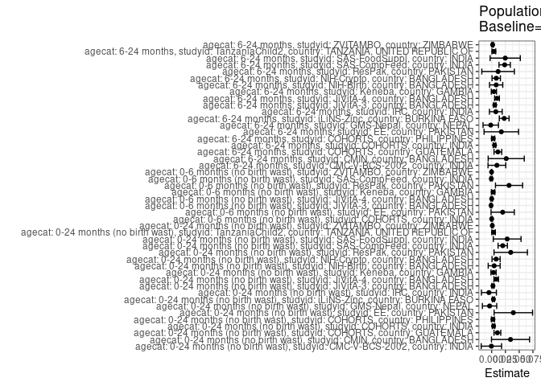

## Results Table

### Parameter: TSM

| agecat | studyid | country | intervention_level | baseline_level | estimate | ci_lower | ci_upper |
| --- | --- | --- | --- | --- | --- | --- | --- |
| 0-24 months (no birth wast) | CMC-V-BCS-2002 | INDIA | 0 | NA | 0.1499864 | 0.1088346 | 0.1911381 |
| 0-24 months (no birth wast) | CMC-V-BCS-2002 | INDIA | 1 | NA | 0.1407190 | 0.0577623 | 0.2236757 |
| 0-24 months (no birth wast) | CMIN | BANGLADESH | 0 | NA | 0.1038186 | 0.0576197 | 0.1500175 |
| 0-24 months (no birth wast) | CMIN | BANGLADESH | 1 | NA | 0.1971871 | 0.1177313 | 0.2766430 |
| 0-24 months (no birth wast) | COHORTS | GUATEMALA | 0 | NA | 0.0098811 | 0.0037745 | 0.0159876 |
| 0-24 months (no birth wast) | COHORTS | GUATEMALA | 1 | NA | 0.0533777 | 0.0282947 | 0.0784607 |
| 0-24 months (no birth wast) | COHORTS | INDIA | 0 | NA | 0.0437566 | 0.0387111 | 0.0488022 |
| 0-24 months (no birth wast) | COHORTS | INDIA | 1 | NA | 0.0714189 | 0.0538824 | 0.0889555 |
| 0-24 months (no birth wast) | COHORTS | PHILIPPINES | 0 | NA | 0.0801255 | 0.0701418 | 0.0901093 |
| 0-24 months (no birth wast) | COHORTS | PHILIPPINES | 1 | NA | 0.1180084 | 0.0697604 | 0.1662564 |
| 0-24 months (no birth wast) | EE | PAKISTAN | 0 | NA | 0.1356812 | 0.0900572 | 0.1813052 |
| 0-24 months (no birth wast) | EE | PAKISTAN | 1 | NA | 0.2307701 | 0.1665489 | 0.2949912 |
| 0-24 months (no birth wast) | GMS-Nepal | NEPAL | 0 | NA | 0.2023183 | 0.1687413 | 0.2358954 |
| 0-24 months (no birth wast) | GMS-Nepal | NEPAL | 1 | NA | 0.1787760 | 0.1030693 | 0.2544828 |
| 0-24 months (no birth wast) | iLiNS-Zinc | BURKINA FASO | 0 | NA | 0.0048951 | 0.0014478 | 0.0083424 |
| 0-24 months (no birth wast) | iLiNS-Zinc | BURKINA FASO | 1 | NA | 0.0200696 | 0.0052216 | 0.0349175 |
| 0-24 months (no birth wast) | IRC | INDIA | 0 | NA | 0.1932773 | 0.1522665 | 0.2342881 |
| 0-24 months (no birth wast) | IRC | INDIA | 1 | NA | 0.1538462 | 0.0556610 | 0.2520313 |
| 0-24 months (no birth wast) | JiVitA-3 | BANGLADESH | 0 | NA | 0.0334114 | 0.0304010 | 0.0364218 |
| 0-24 months (no birth wast) | JiVitA-3 | BANGLADESH | 1 | NA | 0.0404679 | 0.0354820 | 0.0454538 |
| 0-24 months (no birth wast) | JiVitA-4 | BANGLADESH | 0 | NA | 0.0347734 | 0.0280899 | 0.0414569 |
| 0-24 months (no birth wast) | JiVitA-4 | BANGLADESH | 1 | NA | 0.0624533 | 0.0502489 | 0.0746578 |
| 0-24 months (no birth wast) | Keneba | GAMBIA | 0 | NA | 0.1301528 | 0.1170877 | 0.1432179 |
| 0-24 months (no birth wast) | Keneba | GAMBIA | 1 | NA | 0.1685293 | 0.1262472 | 0.2108114 |
| 0-24 months (no birth wast) | NIH-Birth | BANGLADESH | 0 | NA | 0.0851500 | 0.0609331 | 0.1093668 |
| 0-24 months (no birth wast) | NIH-Birth | BANGLADESH | 1 | NA | 0.1185724 | 0.0522745 | 0.1848704 |
| 0-24 months (no birth wast) | NIH-Crypto | BANGLADESH | 0 | NA | 0.0184900 | 0.0081188 | 0.0288612 |
| 0-24 months (no birth wast) | NIH-Crypto | BANGLADESH | 1 | NA | 0.0761905 | 0.0254116 | 0.1269694 |
| 0-24 months (no birth wast) | ResPak | PAKISTAN | 0 | NA | 0.1510766 | 0.1011771 | 0.2009760 |
| 0-24 months (no birth wast) | ResPak | PAKISTAN | 1 | NA | 0.2713060 | 0.1740345 | 0.3685775 |

[output cut: 62 more lines]

### Parameter: E(Y)

| agecat | studyid | country | intervention_level | baseline_level | estimate | ci_lower | ci_upper |
| --- | --- | --- | --- | --- | --- | --- | --- |
| 0-24 months (no birth wast) | CMC-V-BCS-2002 | INDIA | NA | NA | 0.1494565 | 0.1129794 | 0.1859337 |
| 0-24 months (no birth wast) | CMIN | BANGLADESH | NA | NA | 0.1380597 | 0.0966822 | 0.1794372 |
| 0-24 months (no birth wast) | COHORTS | GUATEMALA | NA | NA | 0.0202703 | 0.0126995 | 0.0278411 |
| 0-24 months (no birth wast) | COHORTS | INDIA | NA | NA | 0.0472320 | 0.0423094 | 0.0521545 |
| 0-24 months (no birth wast) | COHORTS | PHILIPPINES | NA | NA | 0.0824776 | 0.0726632 | 0.0922921 |
| 0-24 months (no birth wast) | EE | PAKISTAN | NA | NA | 0.1750663 | 0.1366545 | 0.2134781 |
| 0-24 months (no birth wast) | GMS-Nepal | NEPAL | NA | NA | 0.1984848 | 0.1680322 | 0.2289375 |
| 0-24 months (no birth wast) | iLiNS-Zinc | BURKINA FASO | NA | NA | 0.0080880 | 0.0040249 | 0.0121511 |
| 0-24 months (no birth wast) | IRC | INDIA | NA | NA | 0.1882641 | 0.1503318 | 0.2261964 |
| 0-24 months (no birth wast) | JiVitA-3 | BANGLADESH | NA | NA | 0.0357345 | 0.0331597 | 0.0383093 |
| 0-24 months (no birth wast) | JiVitA-4 | BANGLADESH | NA | NA | 0.0429948 | 0.0372768 | 0.0487128 |
| 0-24 months (no birth wast) | Keneba | GAMBIA | NA | NA | 0.1335425 | 0.1210912 | 0.1459939 |
| 0-24 months (no birth wast) | NIH-Birth | BANGLADESH | NA | NA | 0.0897010 | 0.0668555 | 0.1125465 |
| 0-24 months (no birth wast) | NIH-Crypto | BANGLADESH | NA | NA | 0.0265252 | 0.0150478 | 0.0380026 |
| 0-24 months (no birth wast) | ResPak | PAKISTAN | NA | NA | 0.1857143 | 0.1400836 | 0.2313450 |
| 0-24 months (no birth wast) | SAS-CompFeed | INDIA | NA | NA | 0.1145140 | 0.0913579 | 0.1376700 |
| 0-24 months (no birth wast) | SAS-FoodSuppl | INDIA | NA | NA | 0.1007557 | 0.0711091 | 0.1304022 |
| 0-24 months (no birth wast) | TanzaniaChild2 | TANZANIA, UNITED REPUBLIC OF | NA | NA | 0.0507550 | 0.0419422 | 0.0595679 |
| 0-24 months (no birth wast) | ZVITAMBO | ZIMBABWE | NA | NA | 0.0350517 | 0.0319649 | 0.0381385 |
| 0-6 months (no birth wast) | COHORTS | INDIA | NA | NA | 0.0181260 | 0.0148850 | 0.0213669 |
| 0-6 months (no birth wast) | EE | PAKISTAN | NA | NA | 0.0533333 | 0.0305609 | 0.0761058 |
| 0-6 months (no birth wast) | JiVitA-3 | BANGLADESH | NA | NA | 0.0165815 | 0.0147663 | 0.0183968 |
| 0-6 months (no birth wast) | JiVitA-4 | BANGLADESH | NA | NA | 0.0042364 | 0.0017272 | 0.0067456 |
| 0-6 months (no birth wast) | Keneba | GAMBIA | NA | NA | 0.0391914 | 0.0314649 | 0.0469180 |
| 0-6 months (no birth wast) | ResPak | PAKISTAN | NA | NA | 0.0797101 | 0.0476990 | 0.1117213 |
| 0-6 months (no birth wast) | SAS-CompFeed | INDIA | NA | NA | 0.0312288 | 0.0186884 | 0.0437692 |
| 0-6 months (no birth wast) | ZVITAMBO | ZIMBABWE | NA | NA | 0.0098684 | 0.0081932 | 0.0115436 |
| 6-24 months | CMC-V-BCS-2002 | INDIA | NA | NA | 0.0804290 | 0.0527929 | 0.1080650 |
| 6-24 months | CMIN | BANGLADESH | NA | NA | 0.1150794 | 0.0756007 | 0.1545580 |
| 6-24 months | COHORTS | GUATEMALA | NA | NA | 0.0245902 | 0.0158961 | 0.0332842 |
| 6-24 months | COHORTS | INDIA | NA | NA | 0.0367382 | 0.0323123 | 0.0411641 |
| 6-24 months | COHORTS | PHILIPPINES | NA | NA | 0.0669277 | 0.0576848 | 0.0761707 |
| 6-24 months | EE | PAKISTAN | NA | NA | 0.1363636 | 0.1015372 | 0.1711900 |
| 6-24 months | GMS-Nepal | NEPAL | NA | NA | 0.1898305 | 0.1581595 | 0.2215015 |
| 6-24 months | iLiNS-Zinc | BURKINA FASO | NA | NA | 0.0505205 | 0.0383088 | 0.0627322 |
| 6-24 months | IRC | INDIA | NA | NA | 0.0634146 | 0.0397960 | 0.0870333 |
| 6-24 months | JiVitA-3 | BANGLADESH | NA | NA | 0.0319690 | 0.0290813 | 0.0348568 |
| 6-24 months | JiVitA-4 | BANGLADESH | NA | NA | 0.0440147 | 0.0381801 | 0.0498493 |
| 6-24 months | Keneba | GAMBIA | NA | NA | 0.1172389 | 0.1051866 | 0.1292911 |
| 6-24 months | NIH-Birth | BANGLADESH | NA | NA | 0.0885609 | 0.0646203 | 0.1125014 |
| 6-24 months | NIH-Crypto | BANGLADESH | NA | NA | 0.0273973 | 0.0155476 | 0.0392469 |
| 6-24 months | ResPak | PAKISTAN | NA | NA | 0.1398305 | 0.0954893 | 0.1841717 |
| 6-24 months | SAS-CompFeed | INDIA | NA | NA | 0.0964723 | 0.0729872 | 0.1199573 |
| 6-24 months | SAS-FoodSuppl | INDIA | NA | NA | 0.1268657 | 0.0942904 | 0.1594410 |
| 6-24 months | TanzaniaChild2 | TANZANIA, UNITED REPUBLIC OF | NA | NA | 0.0411298 | 0.0324631 | 0.0497965 |
| 6-24 months | ZVITAMBO | ZIMBABWE | NA | NA | 0.0329172 | 0.0295545 | 0.0362800 |

### Parameter: RR

| agecat | studyid | country | intervention_level | baseline_level | estimate | ci_lower | ci_upper |
| --- | --- | --- | --- | --- | --- | --- | --- |
| 0-24 months (no birth wast) | CMC-V-BCS-2002 | INDIA | 0 | 0 | 1.0000000 | 1.0000000 | 1.000000 |
| 0-24 months (no birth wast) | CMC-V-BCS-2002 | INDIA | 1 | 0 | 0.9382117 | 0.4893498 | 1.798797 |
| 0-24 months (no birth wast) | CMIN | BANGLADESH | 0 | 0 | 1.0000000 | 1.0000000 | 1.000000 |
| 0-24 months (no birth wast) | CMIN | BANGLADESH | 1 | 0 | 1.8993424 | 1.0464040 | 3.447523 |
| 0-24 months (no birth wast) | COHORTS | GUATEMALA | 0 | 0 | 1.0000000 | 1.0000000 | 1.000000 |
| 0-24 months (no birth wast) | COHORTS | GUATEMALA | 1 | 0 | 5.4020057 | 2.4841628 | 11.747083 |
| 0-24 months (no birth wast) | COHORTS | INDIA | 0 | 0 | 1.0000000 | 1.0000000 | 1.000000 |
| 0-24 months (no birth wast) | COHORTS | INDIA | 1 | 0 | 1.6321852 | 1.2444583 | 2.140713 |
| 0-24 months (no birth wast) | COHORTS | PHILIPPINES | 0 | 0 | 1.0000000 | 1.0000000 | 1.000000 |
| 0-24 months (no birth wast) | COHORTS | PHILIPPINES | 1 | 0 | 1.4727941 | 0.9606470 | 2.257981 |
| 0-24 months (no birth wast) | EE | PAKISTAN | 0 | 0 | 1.0000000 | 1.0000000 | 1.000000 |
| 0-24 months (no birth wast) | EE | PAKISTAN | 1 | 0 | 1.7008258 | 1.0980661 | 2.634457 |
| 0-24 months (no birth wast) | GMS-Nepal | NEPAL | 0 | 0 | 1.0000000 | 1.0000000 | 1.000000 |
| 0-24 months (no birth wast) | GMS-Nepal | NEPAL | 1 | 0 | 0.8836373 | 0.5607305 | 1.392496 |
| 0-24 months (no birth wast) | iLiNS-Zinc | BURKINA FASO | 0 | 0 | 1.0000000 | 1.0000000 | 1.000000 |
| 0-24 months (no birth wast) | iLiNS-Zinc | BURKINA FASO | 1 | 0 | 4.0998971 | 1.7094353 | 9.833163 |
| 0-24 months (no birth wast) | IRC | INDIA | 0 | 0 | 1.0000000 | 1.0000000 | 1.000000 |
| 0-24 months (no birth wast) | IRC | INDIA | 1 | 0 | 0.7959866 | 0.4062748 | 1.559522 |
| 0-24 months (no birth wast) | JiVitA-3 | BANGLADESH | 0 | 0 | 1.0000000 | 1.0000000 | 1.000000 |
| 0-24 months (no birth wast) | JiVitA-3 | BANGLADESH | 1 | 0 | 1.2112003 | 1.0435312 | 1.405809 |
| 0-24 months (no birth wast) | JiVitA-4 | BANGLADESH | 0 | 0 | 1.0000000 | 1.0000000 | 1.000000 |
| 0-24 months (no birth wast) | JiVitA-4 | BANGLADESH | 1 | 0 | 1.7960105 | 1.3579002 | 2.375472 |
| 0-24 months (no birth wast) | Keneba | GAMBIA | 0 | 0 | 1.0000000 | 1.0000000 | 1.000000 |
| 0-24 months (no birth wast) | Keneba | GAMBIA | 1 | 0 | 1.2948573 | 0.9884695 | 1.696213 |
| 0-24 months (no birth wast) | NIH-Birth | BANGLADESH | 0 | 0 | 1.0000000 | 1.0000000 | 1.000000 |
| 0-24 months (no birth wast) | NIH-Birth | BANGLADESH | 1 | 0 | 1.3925133 | 0.7446060 | 2.604187 |
| 0-24 months (no birth wast) | NIH-Crypto | BANGLADESH | 0 | 0 | 1.0000000 | 1.0000000 | 1.000000 |
| 0-24 months (no birth wast) | NIH-Crypto | BANGLADESH | 1 | 0 | 4.1206349 | 1.7244576 | 9.846361 |
| 0-24 months (no birth wast) | ResPak | PAKISTAN | 0 | 0 | 1.0000000 | 1.0000000 | 1.000000 |
| 0-24 months (no birth wast) | ResPak | PAKISTAN | 1 | 0 | 1.7958179 | 1.1063660 | 2.914914 |

[output cut: 62 more lines]

### Parameter: PAR

| agecat | studyid | country | intervention_level | baseline_level | estimate | ci_lower | ci_upper |
| --- | --- | --- | --- | --- | --- | --- | --- |
| 0-24 months (no birth wast) | CMC-V-BCS-2002 | INDIA | 0 | NA | -0.0005299 | -0.0190415 | 0.0179817 |
| 0-24 months (no birth wast) | CMIN | BANGLADESH | 0 | NA | 0.0342411 | -0.0003875 | 0.0688696 |
| 0-24 months (no birth wast) | COHORTS | GUATEMALA | 0 | NA | 0.0103892 | 0.0042145 | 0.0165639 |
| 0-24 months (no birth wast) | COHORTS | INDIA | 0 | NA | 0.0034753 | 0.0012797 | 0.0056710 |
| 0-24 months (no birth wast) | COHORTS | PHILIPPINES | 0 | NA | 0.0023521 | -0.0005183 | 0.0052225 |
| 0-24 months (no birth wast) | EE | PAKISTAN | 0 | NA | 0.0393851 | 0.0044295 | 0.0743408 |
| 0-24 months (no birth wast) | GMS-Nepal | NEPAL | 0 | NA | -0.0038335 | -0.0168701 | 0.0092031 |
| 0-24 months (no birth wast) | iLiNS-Zinc | BURKINA FASO | 0 | NA | 0.0031929 | 0.0013412 | 0.0050445 |
| 0-24 months (no birth wast) | IRC | INDIA | 0 | NA | -0.0050133 | -0.0186015 | 0.0085750 |
| 0-24 months (no birth wast) | JiVitA-3 | BANGLADESH | 0 | NA | 0.0023231 | 0.0005445 | 0.0041016 |
| 0-24 months (no birth wast) | JiVitA-4 | BANGLADESH | 0 | NA | 0.0082214 | 0.0040889 | 0.0123540 |
| 0-24 months (no birth wast) | Keneba | GAMBIA | 0 | NA | 0.0033897 | -0.0013255 | 0.0081049 |
| 0-24 months (no birth wast) | NIH-Birth | BANGLADESH | 0 | NA | 0.0045510 | -0.0063185 | 0.0154206 |
| 0-24 months (no birth wast) | NIH-Crypto | BANGLADESH | 0 | NA | 0.0080352 | 0.0006782 | 0.0153922 |
| 0-24 months (no birth wast) | ResPak | PAKISTAN | 0 | NA | 0.0346377 | 0.0042324 | 0.0650430 |
| 0-24 months (no birth wast) | SAS-CompFeed | INDIA | 0 | NA | 0.0200859 | 0.0116053 | 0.0285666 |
| 0-24 months (no birth wast) | SAS-FoodSuppl | INDIA | 0 | NA | 0.0281914 | 0.0029662 | 0.0534166 |
| 0-24 months (no birth wast) | TanzaniaChild2 | TANZANIA, UNITED REPUBLIC OF | 0 | NA | 0.0034638 | 0.0002349 | 0.0066927 |
| 0-24 months (no birth wast) | ZVITAMBO | ZIMBABWE | 0 | NA | 0.0011498 | -0.0000260 | 0.0023255 |
| 0-6 months (no birth wast) | COHORTS | INDIA | 0 | NA | 0.0000447 | -0.0010959 | 0.0011852 |
| 0-6 months (no birth wast) | EE | PAKISTAN | 0 | NA | 0.0200000 | -0.0011581 | 0.0411581 |
| 0-6 months (no birth wast) | JiVitA-3 | BANGLADESH | 0 | NA | -0.0010821 | -0.0022310 | 0.0000669 |
| 0-6 months (no birth wast) | JiVitA-4 | BANGLADESH | 0 | NA | 0.0000300 | -0.0014141 | 0.0014742 |
| 0-6 months (no birth wast) | Keneba | GAMBIA | 0 | NA | 0.0026665 | -0.0004745 | 0.0058075 |
| 0-6 months (no birth wast) | ResPak | PAKISTAN | 0 | NA | 0.0315783 | 0.0069224 | 0.0562341 |
| 0-6 months (no birth wast) | SAS-CompFeed | INDIA | 0 | NA | -0.0006778 | -0.0023836 | 0.0010279 |
| 0-6 months (no birth wast) | ZVITAMBO | ZIMBABWE | 0 | NA | -0.0001577 | -0.0006727 | 0.0003573 |
| 6-24 months | CMC-V-BCS-2002 | INDIA | 0 | NA | 0.0094830 | -0.0066466 | 0.0256126 |
| 6-24 months | CMIN | BANGLADESH | 0 | NA | 0.0264628 | -0.0063592 | 0.0592848 |
| 6-24 months | COHORTS | GUATEMALA | 0 | NA | 0.0112584 | 0.0042579 | 0.0182589 |
| 6-24 months | COHORTS | INDIA | 0 | NA | 0.0051845 | 0.0029253 | 0.0074437 |
| 6-24 months | COHORTS | PHILIPPINES | 0 | NA | 0.0027274 | -0.0001507 | 0.0056054 |
| 6-24 months | EE | PAKISTAN | 0 | NA | 0.0175351 | -0.0138303 | 0.0489005 |
| 6-24 months | GMS-Nepal | NEPAL | 0 | NA | -0.0016873 | -0.0157082 | 0.0123337 |
| 6-24 months | iLiNS-Zinc | BURKINA FASO | 0 | NA | 0.0227719 | 0.0138978 | 0.0316461 |
| 6-24 months | IRC | INDIA | 0 | NA | 0.0075487 | -0.0040444 | 0.0191418 |
| 6-24 months | JiVitA-3 | BANGLADESH | 0 | NA | 0.0056865 | 0.0035176 | 0.0078553 |
| 6-24 months | JiVitA-4 | BANGLADESH | 0 | NA | 0.0096883 | 0.0053460 | 0.0140306 |
| 6-24 months | Keneba | GAMBIA | 0 | NA | 0.0040325 | -0.0007224 | 0.0087873 |
| 6-24 months | NIH-Birth | BANGLADESH | 0 | NA | 0.0081351 | -0.0038777 | 0.0201480 |
| 6-24 months | NIH-Crypto | BANGLADESH | 0 | NA | 0.0082585 | 0.0006596 | 0.0158574 |
| 6-24 months | ResPak | PAKISTAN | 0 | NA | 0.0116790 | -0.0179379 | 0.0412959 |
| 6-24 months | SAS-CompFeed | INDIA | 0 | NA | 0.0236495 | 0.0133640 | 0.0339349 |
| 6-24 months | SAS-FoodSuppl | INDIA | 0 | NA | 0.0246373 | -0.0027969 | 0.0520714 |
| 6-24 months | TanzaniaChild2 | TANZANIA, UNITED REPUBLIC OF | 0 | NA | 0.0039369 | 0.0004866 | 0.0073873 |
| 6-24 months | ZVITAMBO | ZIMBABWE | 0 | NA | 0.0017383 | 0.0003541 | 0.0031225 |

### Parameter: PAF

| agecat | studyid | country | intervention_level | baseline_level | estimate | ci_lower | ci_upper |
| --- | --- | --- | --- | --- | --- | --- | --- |
| 0-24 months (no birth wast) | CMC-V-BCS-2002 | INDIA | 0 | NA | -0.0035452 | -0.1353613 | 0.1129669 |
| 0-24 months (no birth wast) | CMIN | BANGLADESH | 0 | NA | 0.2480163 | -0.0367872 | 0.4545849 |
| 0-24 months (no birth wast) | COHORTS | GUATEMALA | 0 | NA | 0.5125330 | 0.2048383 | 0.7011626 |
| 0-24 months (no birth wast) | COHORTS | INDIA | 0 | NA | 0.0735797 | 0.0265876 | 0.1183031 |
| 0-24 months (no birth wast) | COHORTS | PHILIPPINES | 0 | NA | 0.0285179 | -0.0067811 | 0.0625793 |
| 0-24 months (no birth wast) | EE | PAKISTAN | 0 | NA | 0.2249726 | 0.0040411 | 0.3968953 |
| 0-24 months (no birth wast) | GMS-Nepal | NEPAL | 0 | NA | -0.0193138 | -0.0871080 | 0.0442526 |
| 0-24 months (no birth wast) | iLiNS-Zinc | BURKINA FASO | 0 | NA | 0.3947650 | 0.1469716 | 0.5705778 |
| 0-24 months (no birth wast) | IRC | INDIA | 0 | NA | -0.0266288 | -0.1012912 | 0.0429717 |
| 0-24 months (no birth wast) | JiVitA-3 | BANGLADESH | 0 | NA | 0.0650097 | 0.0140520 | 0.1133336 |
| 0-24 months (no birth wast) | JiVitA-4 | BANGLADESH | 0 | NA | 0.1912194 | 0.0884635 | 0.2823919 |
| 0-24 months (no birth wast) | Keneba | GAMBIA | 0 | NA | 0.0253832 | -0.0105177 | 0.0600086 |
| 0-24 months (no birth wast) | NIH-Birth | BANGLADESH | 0 | NA | 0.0507357 | -0.0777098 | 0.1638725 |
| 0-24 months (no birth wast) | NIH-Crypto | BANGLADESH | 0 | NA | 0.3029276 | 0.0082660 | 0.5100400 |
| 0-24 months (no birth wast) | ResPak | PAKISTAN | 0 | NA | 0.1865109 | 0.0077575 | 0.3330616 |
| 0-24 months (no birth wast) | SAS-CompFeed | INDIA | 0 | NA | 0.1754015 | 0.1064929 | 0.2389958 |
| 0-24 months (no birth wast) | SAS-FoodSuppl | INDIA | 0 | NA | 0.2797999 | -0.0053812 | 0.4840881 |
| 0-24 months (no birth wast) | TanzaniaChild2 | TANZANIA, UNITED REPUBLIC OF | 0 | NA | 0.0682452 | 0.0034944 | 0.1287887 |
| 0-24 months (no birth wast) | ZVITAMBO | ZIMBABWE | 0 | NA | 0.0328017 | -0.0012084 | 0.0656564 |
| 0-6 months (no birth wast) | COHORTS | INDIA | 0 | NA | 0.0024640 | -0.0624881 | 0.0634453 |
| 0-6 months (no birth wast) | EE | PAKISTAN | 0 | NA | 0.3750000 | -0.1215451 | 0.6517082 |
| 0-6 months (no birth wast) | JiVitA-3 | BANGLADESH | 0 | NA | -0.0652583 | -0.1362963 | 0.0013387 |
| 0-6 months (no birth wast) | JiVitA-4 | BANGLADESH | 0 | NA | 0.0070908 | -0.4007295 | 0.2961748 |
| 0-6 months (no birth wast) | Keneba | GAMBIA | 0 | NA | 0.0680382 | -0.0145451 | 0.1438994 |
| 0-6 months (no birth wast) | ResPak | PAKISTAN | 0 | NA | 0.3961637 | 0.0497226 | 0.6163033 |
| 0-6 months (no birth wast) | SAS-CompFeed | INDIA | 0 | NA | -0.0217055 | -0.0768843 | 0.0306459 |
| 0-6 months (no birth wast) | ZVITAMBO | ZIMBABWE | 0 | NA | -0.0159834 | -0.0694537 | 0.0348134 |
| 6-24 months | CMC-V-BCS-2002 | INDIA | 0 | NA | 0.1179054 | -0.1028925 | 0.2944998 |
| 6-24 months | CMIN | BANGLADESH | 0 | NA | 0.2299526 | -0.1024494 | 0.4621313 |
| 6-24 months | COHORTS | GUATEMALA | 0 | NA | 0.4578410 | 0.1626674 | 0.6489611 |
| 6-24 months | COHORTS | INDIA | 0 | NA | 0.1411191 | 0.0799463 | 0.1982246 |
| 6-24 months | COHORTS | PHILIPPINES | 0 | NA | 0.0407508 | -0.0029043 | 0.0825057 |
| 6-24 months | EE | PAKISTAN | 0 | NA | 0.1285907 | -0.1310428 | 0.3286247 |
| 6-24 months | GMS-Nepal | NEPAL | 0 | NA | -0.0088884 | -0.0855234 | 0.0623364 |
| 6-24 months | iLiNS-Zinc | BURKINA FASO | 0 | NA | 0.4507461 | 0.2712513 | 0.5860304 |
| 6-24 months | IRC | INDIA | 0 | NA | 0.1190374 | -0.0782406 | 0.2802208 |
| 6-24 months | JiVitA-3 | BANGLADESH | 0 | NA | 0.1778745 | 0.1101633 | 0.2404332 |
| 6-24 months | JiVitA-4 | BANGLADESH | 0 | NA | 0.2201146 | 0.1167627 | 0.3113728 |
| 6-24 months | Keneba | GAMBIA | 0 | NA | 0.0343952 | -0.0069023 | 0.0739989 |
| 6-24 months | NIH-Birth | BANGLADESH | 0 | NA | 0.0918593 | -0.0526376 | 0.2165210 |
| 6-24 months | NIH-Crypto | BANGLADESH | 0 | NA | 0.3014354 | 0.0063132 | 0.5089071 |
| 6-24 months | ResPak | PAKISTAN | 0 | NA | 0.0835225 | -0.1531762 | 0.2716369 |
| 6-24 months | SAS-CompFeed | INDIA | 0 | NA | 0.2451427 | 0.1153418 | 0.3558987 |
| 6-24 months | SAS-FoodSuppl | INDIA | 0 | NA | 0.1941995 | -0.0486272 | 0.3807958 |
| 6-24 months | TanzaniaChild2 | TANZANIA, UNITED REPUBLIC OF | 0 | NA | 0.0957198 | 0.0102582 | 0.1738020 |
| 6-24 months | ZVITAMBO | ZIMBABWE | 0 | NA | 0.0528081 | 0.0101591 | 0.0936194 |